# Euro/USD Example

2024-09-18

Load Packages

Import Euro/USD data

This data is given to us in the form of: Date (day, month, year), Time (5-minute time intervals), Euro/USD bid price, Euro/USD ask price.

The data is already clean and well-formatted in date, time form; however, it gives us the Euro/USD bid and ask prices, not returns, therefore we must calculate Returns from this data.

```r
exchange <- read.csv("EuroUSD.csv")
exchange <- as.data.frame(exchange)
```

Creating data frame

```r
v1_updated <- c(exchange[[1]])  # Date
v2_updated <- c(exchange[[2]])  # Time
v3_updated <- c(exchange[[3]])  # Bid
v4_updated <- c(exchange[[4]])  # Ask
```

Giving columns correct headers

```r
exchange_updated <- data.frame(v1_updated, v2_updated, v3_updated, v4_updated)
colnames(exchange_updated) <- c("Date", "Time", "Bid", "Ask")
```

## Calendar cleaning

Set date column as day, month, year to make calendar cleaning easier.

```r
exchange_updated$Date <- as.Date(exchange_updated$Date, format="%d.%m.%Y")
exchange_updated$DayOfWeek <- weekdays(exchange_updated$Date)

exchange_updated <- exchange_updated[!(exchange_updated$DayOfWeek == "Saturday" | exchange_updated$DayOfWeek == "Sunday"), ]
```

Clean out Christmas

```r
exchange_updated <- exchange_updated[!(format(exchange_updated$Date, "%m") == "12" & format(exchange_updated$Date, "%d") %in% c("24", "25", "26")), ]
```

Clean out New Years

```r
exchange_updated <- exchange_updated[!(format(exchange_updated$Date, "%m") == "12" & format(exchange_updated$Date, "%d") == "31"), ]
exchange_updated <- exchange_updated[!(format(exchange_updated$Date, "%m") == "01" & format(exchange_updated$Date, "%d") %in% c("01", "02")), ]
```

Clean out July 4th

```r
exchange_updated <- exchange_updated[!(format(exchange_updated$Date, "%m") == "07" & format(exchange_updated$Date, "%d") == "04"), ]
```

Clean out Labor Day

```r
labor_day_dates <- as.Date(c(
  "2007-09-03", "2008-09-01", "2009-09-07", "2010-09-06", "2011-09-05",
  "2012-09-03", "2013-09-02", "2014-09-01", "2015-09-07", "2016-09-05", "2017-09-04"))

exchange_updated <- exchange_updated[!(exchange_updated$Date %in% labor_day_dates), ]
```

Clean out Thanksgiving

```r
thanksgiving_day_dates <- as.Date(c("2007-11-22",
  "2008-11-27", "2009-11-26", "2010-11-25", "2011-11-24", "2012-11-22",
  "2013-11-28", "2014-11-27", "2015-11-26", "2016-11-24", "2017-11-23"))

exchange_updated <- exchange_updated[!(exchange_updated$Date %in% thanksgiving_day_dates), ]
```

Clean out after Thanksgiving

```r
thanksgiving_day_dates_2 <- as.Date(c("2007-11-23",
  "2008-11-28", "2009-11-27", "2010-11-26", "2011-11-25", "2012-11-23",
  "2013-11-29", "2014-11-28", "2015-11-27", "2016-11-25", "2017-11-24"))

exchange_updated <- exchange_updated[!(exchange_updated$Date %in% thanksgiving_day_dates_2), ]
```

Clean out Memorial Day

```r
memorial_day_dates <- as.Date(c("2007-05-28", "2008-05-26", "2009-05-25", "2010-05-31", "2011-05-30", "2012-05-28",
  "2013-05-27", "2014-05-26", "2015-05-25", "2016-05-30", "2017-05-29"))

exchange_updated <- exchange_updated[!(exchange_updated$Date %in% memorial_day_dates), ]
```

Clean out Good Fridays

```r
good_friday_dates <- as.Date(c("2007-04-06", "2008-03-21", "2009-04-10", "2010-04-02", "2011-04-22", "2012-04-06", "2013-03-29", "2014-04-18", "2015-04-03", "2016-03-25", "2017-04-14"))

exchange_updated <- exchange_updated[!(exchange_updated$Date %in% good_friday_dates), ]
```

Clean out Monday after Easter

```r
easter_sunday_dates <- as.Date(c("2007-04-08", "2008-03-23", "2009-04-12", "2010-04-04", "2011-04-24", "2012-04-08", "2013-03-31", "2014-04-20", "2015-04-05", "2016-03-27", "2017-04-16"))

easter_monday_dates <- easter_sunday_dates + 1

exchange_updated <- exchange_updated[!(exchange_updated$Date %in% easter_monday_dates), ]
```

Clean out random July 4ths

```r
exchange_updated <- exchange_updated[!(month(exchange_updated$Date) == 7 & day(exchange_updated$Date) == 3 & year(exchange_updated$Date) %in% c(2009, 2015)), ]

exchange_updated <- exchange_updated[, !names(exchange_updated) %in% "weekday"]
```

Calculate Daily Forex Spread

```r
exchange_updated$Spread <- exchange_updated$Ask - exchange_updated$Bid

spread = exchange_updated$Spread

daily_spread = numeric()

daily_spread[1] = sum(spread[1:288])

for(i in 2:2463) {
  n = (i-1) * 288 + 1
  m = i * 288
  daily_spread[i] = sum(spread[n:m])
}
```

Plot daily Forex Spread

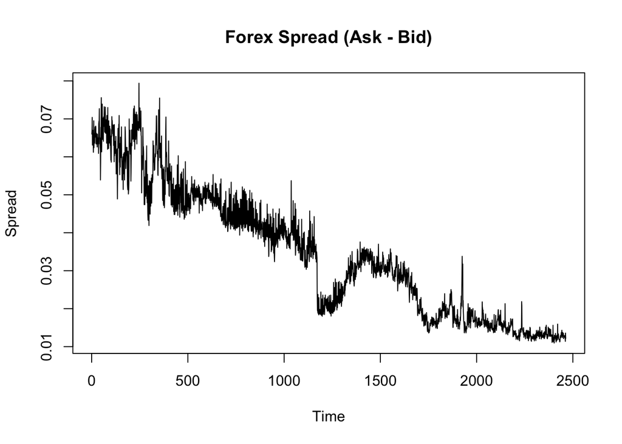

```r
plot.ts(daily_spread, main="Forex Spread (Ask - Bid)", ylab="Spread", xlab="Time")
```

Calculate geometric mean function using the given formula:

$$(log(bid) + log(ask))/2$$

```r
calculate_geometric_mean <- function(bid, ask){
  geometric_mean <- (log(bid) + log(ask))/2
  return(geometric_mean)
}
```

Calculating geometric mean

```r
geometric_mean <- calculate_geometric_mean(exchange_updated$Bid, exchange_updated$Ask)
```

Calculate returns function that finds the difference of the consecutive logs.

```r
calculate_daily_returns <- function(geometric_mean){
  daily_return <- numeric(length(geometric_mean) - 1)
  for (i in 2:length(geometric_mean)) {
    daily_return[i-1] <- geometric_mean[i] - geometric_mean[i-1]
  }
  return(daily_return)
}
```

Calculating returns and updating data frame

```r
returns <- calculate_daily_returns(geometric_mean)

exchange_updated$Returns <- c(0, returns)
```

Clearing out 15 longest runs of zeros

```r
zero_runs <- rle(exchange_updated$Returns == 0)

zero_runs_df <- data.frame(
  lengths = zero_runs$lengths,
  values = zero_runs$values,
  start_positions = cumsum(c(1, head(zero_runs$lengths, -1)))
)

longest_zero_runs <- zero_runs_df[zero_runs_df$values == TRUE, ]
longest_zero_runs <- longest_zero_runs[order(-longest_zero_runs$lengths), ]

longest_zero_runs <- head(longest_zero_runs, 15)

for (i in 1:nrow(longest_zero_runs)) {
  start <- longest_zero_runs$start_positions[i]
  end <- start + longest_zero_runs$lengths[i] - 1
  exchange_updated <- exchange_updated[-(start:end), ]
}

exchange_updated <- exchange_updated
```

Plot returns

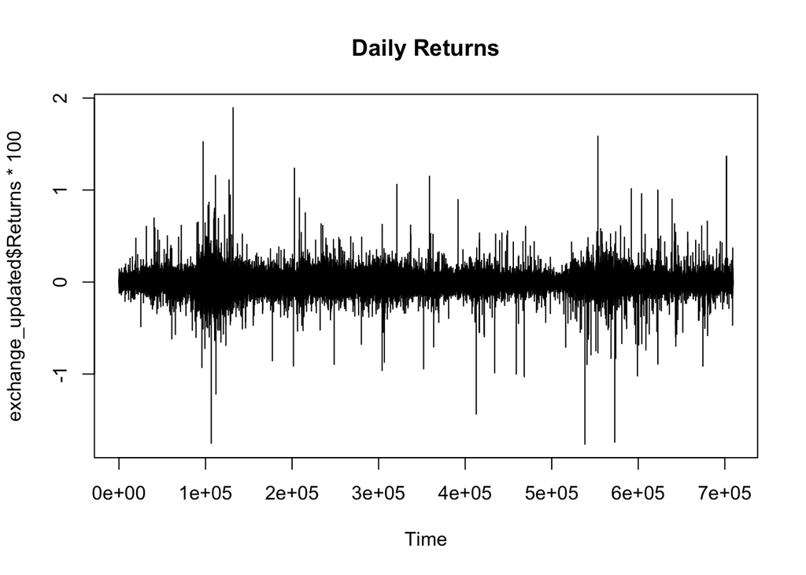

```r
plot.ts(exchange_updated$Returns*100, main="Daily Returns")
```

Calculating realized volatility

```r
return_sq=(exchange_updated$Returns*100)^2

vard=0;
vard[1]=sum(return_sq[1:288])
for(i in 2:2463) {
  n=(i-1)*288; m=i*288
vard[i]=sum(return_sq[n:m])
}
```

```r
variance=vard[1:2463];

realized_volatility=sqrt(variance)
```

Plot variance

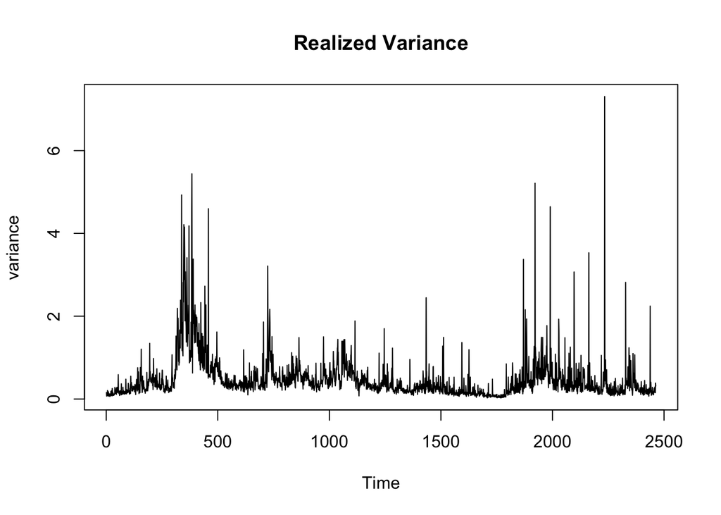

```r
plot.ts(variance, main="Realized Variance")
```

Plot Realized Volatility

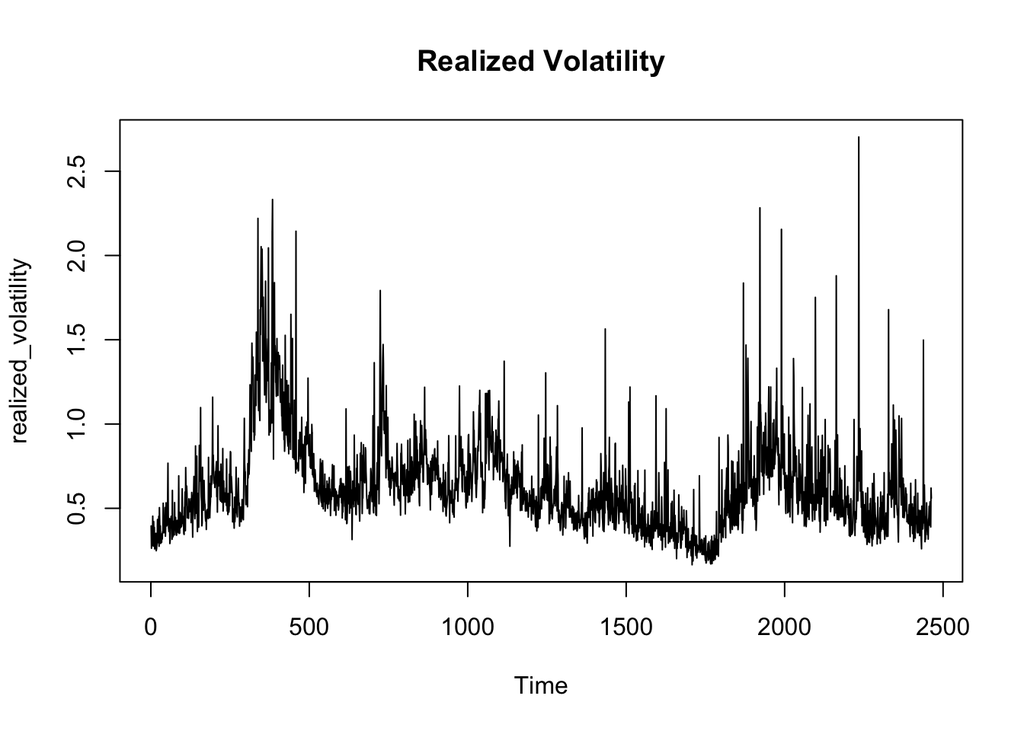

```r
plot.ts(realized_volatility, main="Realized Volatility")
```

Estimating $a$ and Recovering increments functions

```r
Estimated_MLE<-function(data,N,M, sigma)
{
  Delta_1L<- numeric(N);
  S_nM<- numeric(N);
  S_nMean<- numeric(N)
  S_nM[1]=sum(data[1:M]);
  for(n in 2:N) {
    i=(n-1)*M+1; up=n*M;
    S_nM[n] <- sum(data[floor(i):floor(up)])
  }
  S_nMean<- S_nM-mean(S_nM);
  phi_1<- (sum(S_nMean[1:N-1]*S_nMean[2:N]))/(sum(S_nMean^2));
  data=data-mean(data)
  R=length(data)
  phi_Y= (sum(data[1:R-1]*data[2:R]))/(sum(data^2))
  a_hat=-M*phi_Y+M;
  out<- a_hat;
}
```

```r
Estimated_Log<-function(data, N, M){
  R = length(data);
  diff=log(data[1:R-1])-log(data[2:R]);
  a_hat=M*(max(diff));
  out<- a_hat;
}
```

```r
Recovered_Increments<-function(data,N,a,M,sigma)
{
  Delta_1L<- numeric(N);
  Delta_1L[1]<-(a/(M*sigma))*sum(data[1:M])+(1/sigma-a/(2*M*sigma))*(data[M]-data[1]);
  for(n in 2:N) {
    i=(n-1)*M+1; up=n*M;
    Delta_1L[n] <-
      (a/(M*sigma))*sum(data[floor(i):floor(up)])+(1/sigma-a/(2*M*sigma))*(data[up]-data[i-1])
  }
  out<-Delta_1L;
}
```

Estimating a and recovering increments

```r
N=2463
M=70
sigma <- 1
L <- realized_volatility
a_h <- Estimated_Log(L, N, M)
#a_h <- Estimated_MLE(L, N, M, sigma)
recovered_increments <- Recovered_Increments(L, N, a=a_h, M, sigma)
recovered_increments <- na.omit(recovered_increments)
```

Plotting recovered increments

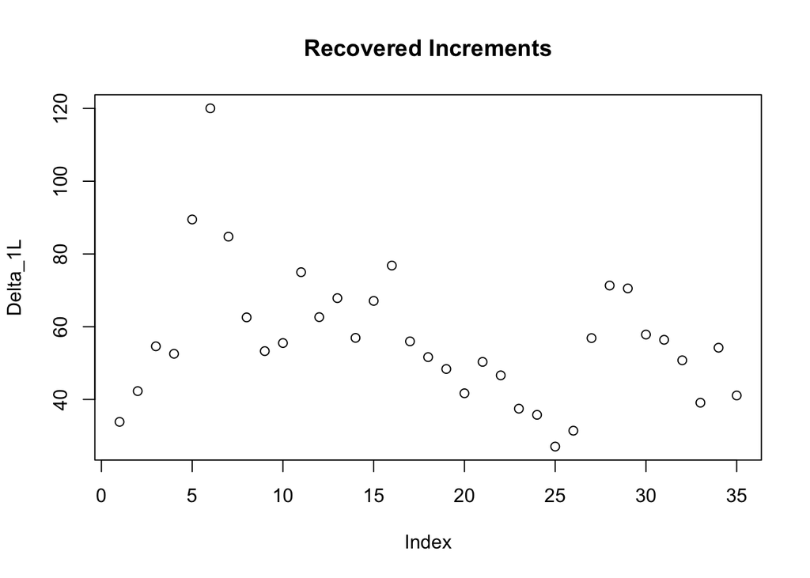

```r
Delta_1L <- recovered_increments

plot(Delta_1L,main="Recovered Increments")
```

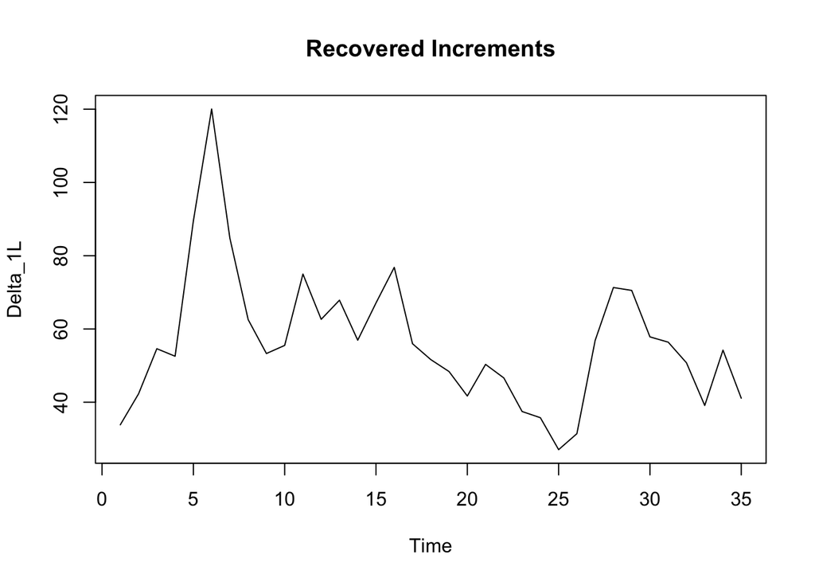

```r
plot.ts(Delta_1L,main="Recovered Increments")
```

```r
CARMA_MC<-function(R,N,alpha)
{
  quantile=qnorm(1-alpha/2);
  counter_1=0;
  a_hatMLE=c();
  for(i in 1:R)
  {
    a_1L=acf(Delta_1L, plot = FALSE);
    if(abs(sqrt(N)*a_1L$acf[2])>quantile){counter_1=counter_1+1};
    a_hatMLE[i]=a_h;
  }
  freq_1=counter_1/R;
  print(c(freq_1));
  #print(a_hatMLE)
  #print(a_1L)
}
```

Testing

```r
N <- 35
alpha <- 0.05
CARMA_MC(R=1,N,alpha )
```

```
## [1] 1
```

ACF plot

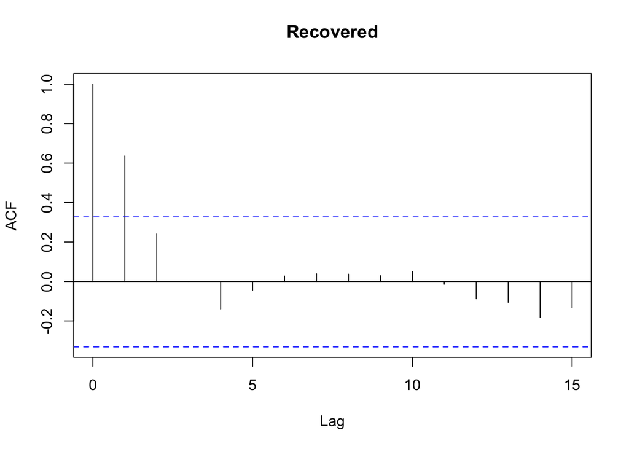

```r
acf(Delta_1L,main="Recovered")
```

Calculating test statistic

```r
calculate_test_statistic <- function(Delta_1L, N) {
  a_1L <- acf(Delta_1L, plot = FALSE)
  test_stat <- abs(sqrt(N) * a_1L$acf[2])
  return(test_stat)
}
calculate_test_statistic(Delta_1L, N)
```

```
## [1] 3.761705
```

KS Test procedure 1

```r
KS_test<-function(R=10,N=100,K=5000,M=100,mu=0,a=0.9,eta=1,sigma=1,alpha=0.05)
        {
        counter_2=0;
        for(i in 1:R)
                {
                Delta_1L_sample<- sample(Delta_1L, replace=T);
                mu_hat=mean(Delta_1L);
                eta_hat_sqrt=mean((Delta_1L-mu_hat)^2);
                a_1L=ks.test(Delta_1L,"pnorm", mu_hat, sqrt(eta_hat_sqrt));
                a_1L=a_1L$p.value;
                if(a_1L<0.05){counter_2=counter_2+1};
                }
        freq_2=counter_2/R;
        print(freq_2);
        print(a_1L)
}
```

```r
KS_test(R=1)
```

```
## [1] 0
## [1] 0.3155226
```